# MTH6139 Time Series Coursework 1

Meta’s Prophet Forcasting System

Pradeep Mohan

Spring term 2025

# 1 Purpose

We are going to explore 2 time series using Meta’s Prophet forecasting system.It is a tool that would make accurate prediction on future values in any time series data using a simple parameters. It is fast,easy and can handle with any errors such as missing values.It can be modelled in weeks, months or years and depends on trends, seasonality, holiday and error.

# 2 Mauna Lou Atmospheric CO2 Concentration

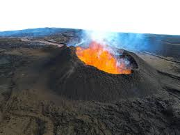

One of the largest active volcano in Hawaii

## 2.1 Introduction

Manua Loa is an active and shield volcano in the US state of Hawaii. It is one of the largest volcano by both mass and volume- which is 75000 cubic kilometre. It records how much atmospheric concentrations of CO2 are released from Mauna Loa in parts per million (ppm). It is already stored in R as ‘co2’ A time series of 468 observations is recorded from 1959 to 1997 and is recorded monthly. However, there are few observations from 1964 is missing and therefore is obtained by interpolation. The usage of r code “co2” is where the data of 468 observations of the amount of CO2 concentration released is stored.

## 2.2 Predicting the values

We want to know the predictions of the amount of CO2 concentration is released into the atmosphere in 1998 and 1999. So, we would use Prophet’s forecasting system to find the prediction.

```r
dataFrame = data.frame(ds=zoo::as.yearmon(time(co2)),y=co2)#Creating this time series into data frame
model = prophet::prophet(dataFrame)
```

```
## Disabling weekly seasonality. Run prophet with weekly.seasonality=TRUE to override this.
```

```
## Disabling daily seasonality. Run prophet with daily.seasonality=TRUE to override this.
```

```r
future = prophet::make_future_dataframe(model, periods=24, freq="month")#It creates future dates of 1998 and 1999 monthly.
forecast = predict(model, future)#It adds 24 future values into the data frame.
tail(forecast[c('ds', 'yhat', 'yhat_lower', 'yhat_upper')])# Only showing the last 6 dates and its predicted values.
```

```
##             ds     yhat yhat_lower yhat_upper
## 487 1999-07-01 367.2786   366.5820   367.9582
## 488 1999-08-01 365.4006   364.6487   366.1761
## 489 1999-09-01 363.7046   362.8885   364.4770
## 490 1999-10-01 363.5118   362.6899   364.3554
## 491 1999-11-01 364.9055   364.0942   365.7145
## 492 1999-12-01 366.1360   365.1928   367.0588
```

The code ‘make_future_dataframe’ is where future dates is created in number of periods you picked.

## 2.3 Plot

### 2.3.1 Display

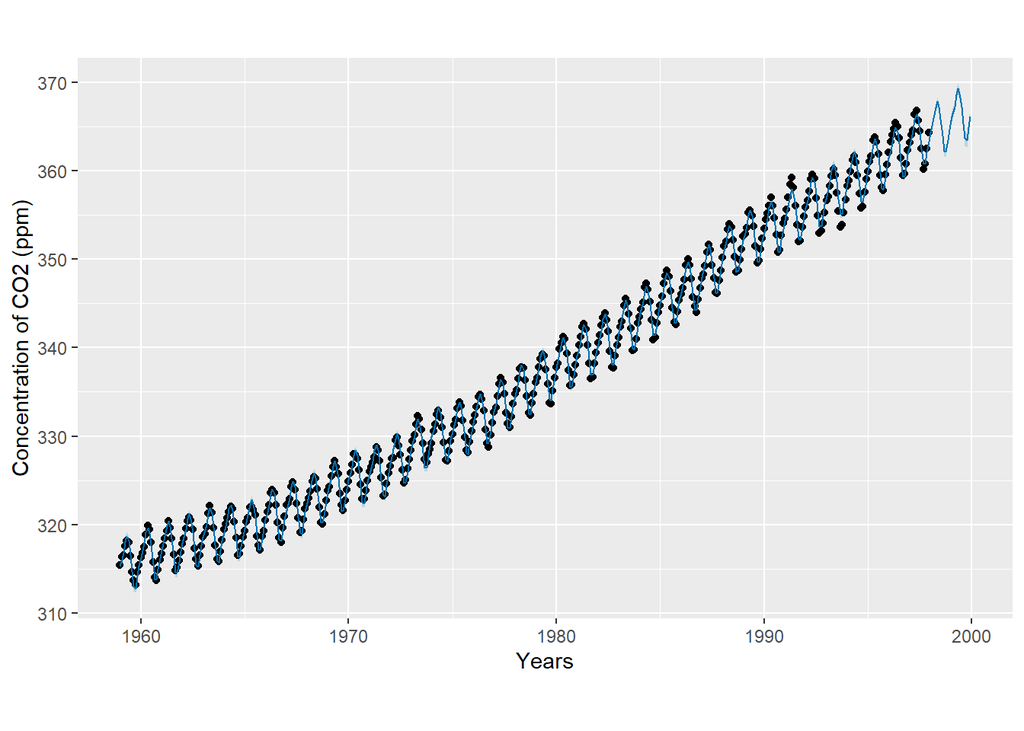

```r
plot(model,forecast, xlab="Years", ylab="Concentration of CO2 (ppm)",main="Mauna Loa Atmospheric CO2 Concentration")
```

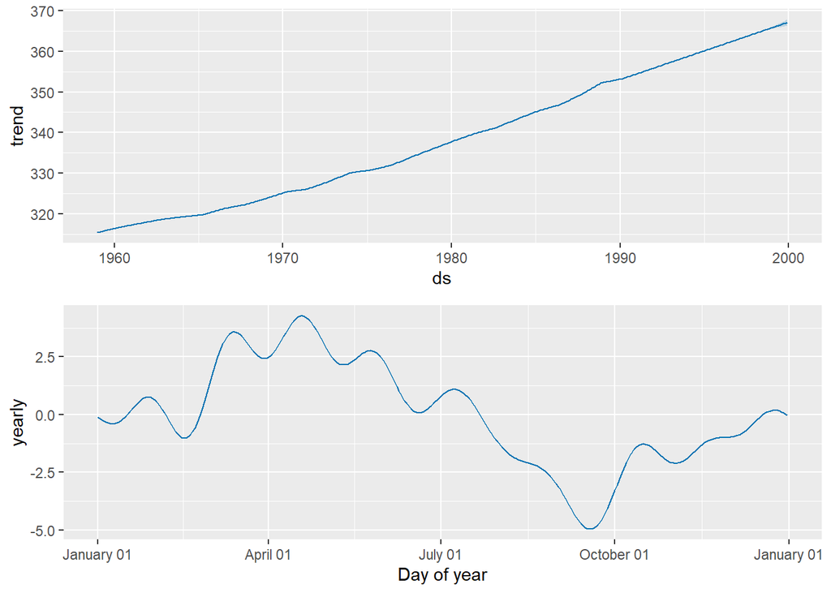

```r
prophet::prophet_plot_components(model, forecast)#Broke dowm into trend and yearly seasonality.
```

### 2.3.2 Dygraph

```r
library(dygraphs)
prediction<-forecast[c('ds', 'yhat', 'yhat_lower', 'yhat_upper')]#Predicted values
dygraph(prediction, main = "New Concentration") %>% dyRangeSelector(dateWindow = c("1998-01-01", "1999-12-01"))# Dygraph showing the predictions in 1998 and 1999 with upper bound and lower bound
```

[interactive chart not shown]

The dygraph shows the predictions of the values of CO2 concentration being released to the atmosphere. We can tell that it follows the same pattern as the original observations.

## 2.4 Reference

https://scrippsco2.ucsd.edu/data/atmospheric_co2/.

# 3 Peyton Manning’s Wikipedia Page

[figure not shown]

Peyton Manning

## 3.1 Introduction

The forecasting system can also be use to show the time series of how many people have visited on one Wikipedia page and is capable of showing multiple seasonality and growth rates. A Wikipedia page of a former NFL player Peyton Manning is one of the example.He is one of NFL greatest quarterbacks of all time. He played for Indianapolis Colts for 14 seasons and Denver Broncos for 4 seasons before retiring in 2016. A time series showing the data of daily views of Peyton Manning is stored on this website: https://github.com/facebook/prophet/blob/main/examples/example_wp_log_peyton_manning.csv This time series shows 2905 observations taken from 10th December 2007 to 20 January 2016 daily. Because of high differences in number of views between one date and another date, it could lead to lots of anomalous values,log transformations was used in order to stabilise the variance. Therefore daily views were taken in log.

## 3.2 Predicting the future values

We would want to know how the views of Wikipedia changes for 1 year to January 2017. So we would use the prophet forecasting system to find out.

```r
dataFrame2 <- read.csv('https://raw.githubusercontent.com/facebook/prophet/main/examples/example_wp_log_peyton_manning.csv')#Creating this time series from the website into data frame.
model2 = prophet::prophet(dataFrame2)
```

```
## Disabling daily seasonality. Run prophet with daily.seasonality=TRUE to override this.
```

```r
future2 = prophet::make_future_dataframe(model2, periods=365)#It creates future dates from 21st January to 20th January 2017.
forecast2 = predict(model2, future2)#It adds 24 future values into the data frame.
tail(forecast2[c('ds', 'yhat', 'yhat_lower', 'yhat_upper')])# Only showing the last 6 future dates with predicted values.
```

```
##              ds     yhat yhat_lower yhat_upper
## 3265 2017-01-14 7.827290   7.139607   8.611769
## 3266 2017-01-15 8.209113   7.460999   8.925736
## 3267 2017-01-16 8.534106   7.861806   9.201423
## 3268 2017-01-17 8.321526   7.592645   9.033572
## 3269 2017-01-18 8.154180   7.374126   8.789740
## 3270 2017-01-19 8.166079   7.515463   8.864418
```

The futures dates indicate an decrease in numbers on views. This could be due to his retirement.

## 3.3 Graphs

### 3.3.1 Plots

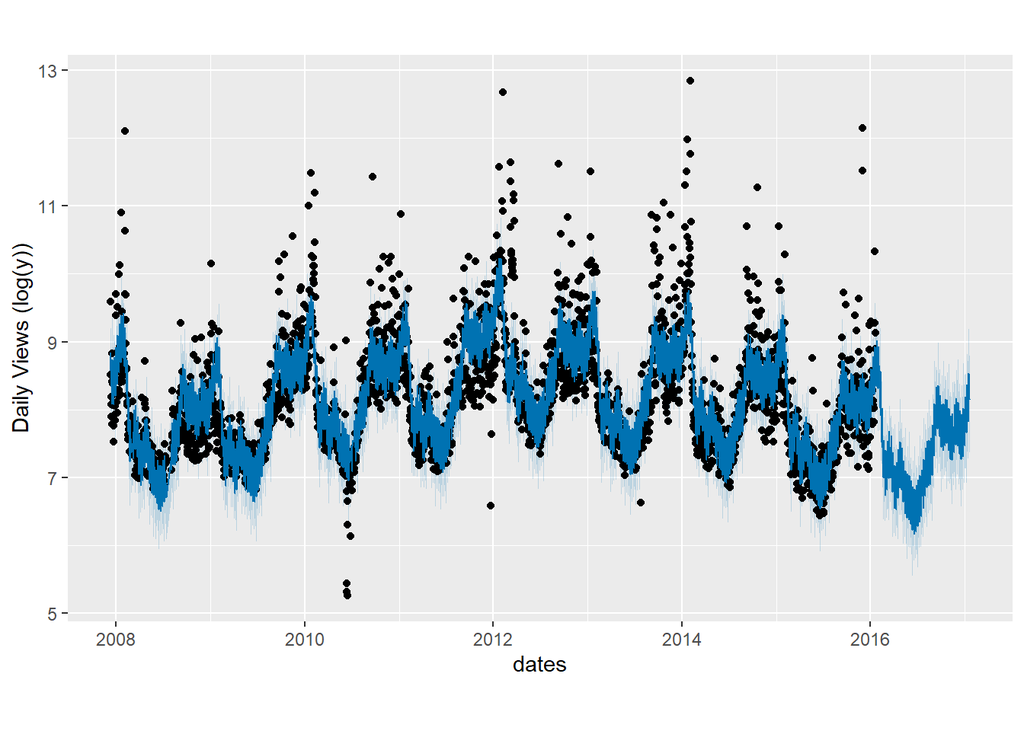

```r
plot(model2, forecast2,xlab="dates",ylab="Daily Views (log(y))",main="Peyton Mannings")
```

In this graph,the daily views is fairly constant throughout the years between around 6.5 and 10(665 and 22,026). But, in some days, there were more people visited Peyton Manning’s Wikipedia pages as high as around 12.8(362,217 views) because of his achievement and performances in one of his matches. Sometimes, the views were lower, with the lowest being 5.3(200 views).

### 3.3.2 Seasonality

We can further broke down into trend and 2 seasonality: weekly and yearly.

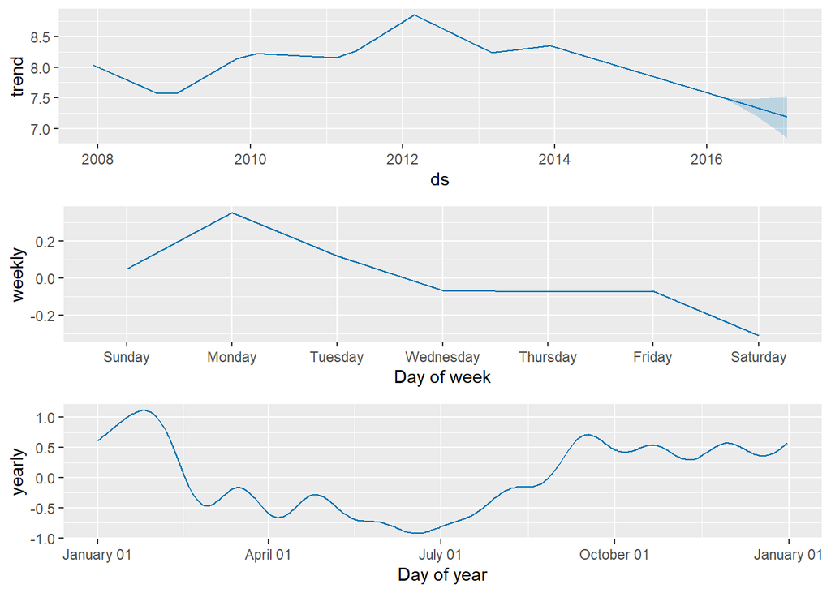

```r
prophet::prophet_plot_components(model2, forecast2)#Graph broken down into 2 sesonalities and trend.
```

#### 3.3.2.3 Yearly Seasonality

Any season of NFL start in weekend following Labor’s Day in September with a regular season and ends with Super Bowl in 2nd Sunday of February. Regular season ends in January, when play-offs began. There’s no NFL matches from after Super Bowl. So less people would look at any Wikipedia pages, including Peyton Manning, from the end of Super Bowl. Therefore, this would lead to decrease in trend. But, when pre-season starts, trends rises meaning people would then look at Manning’s Wikipedia page and rapidly increases back to positive when regular season starts. The highest peak is around the start of February where play-off season and Super Bowl take place.

### 3.3.3 Dynamic plots

```r
prophet::dyplot.prophet(model2, forecast2)# Dygraph showing trends including predicted values and dates from 2016 to 2017.
```

[interactive chart not shown]

The dygraph shows the interactive forecast of this time series. It can be use to explore the predicted value in depth by moving timeline so that we can see how the prediction goes.

## 3.4 Sources

Wikipedia page: https://en.wikipedia.org/wiki/Peyton_Manning

Data from GitHub: https://github.com/facebook/prophet/blob/main/examples/example_wp_log_peyton_manning.csv

# 4 Comparision